# Milestone Report for Week 2 of the Capstone Project

## Introduction and Motivation

This report is an introduction to the capstone porject. It will discuss some of the exploratory analysis I have done, some of the processing steps I have taken, future processing steps needed, and some exploratory graphs and tables.

I hope this provides you with a good overview of the first steps of the project without being too technical.

## Exploratory Analysis

After the data was downloaded, extracted, and read in, I began the exploratory analysis of the English data sets.

First, I checked to see how many rows each of the files had.

Twitter:

```r
nrow(df_twitter)
```

```
## [1] 2360148
```

Blogs:

```r
nrow(df_blogs)
```

```
## [1] 899288
```

News:

```r
nrow(df_news)
```

```
## [1] 77259
```

Twitter:

```r
sum(grepl(" ", data_twitter))
```

```
## [1] 2358901
```

Blogs:

```r
sum(grepl(" ", data_blogs))
```

```
## [1] 888019
```

News:

```r
sum(grepl(" ", data_news))
```

```
## [1] 76987
```

```r
longest <- which.max(nchar(data_blogs))
nchar(data_blogs[longest])
```

```
## [1] 40835
```

Also, here is the making of a dataframe of all the words and their frequencies, followed by a table showing the top 20 words, and then a bar plot showing the top ten words. This processing was in preparation for a word cloud. The steps taken were borrowed from http://www.sthda.com/english/wiki/text-mining-and-word-cloud-fundamentals-in-r-5-simple-steps-you-should-know

```r
library(tm)
twit_temp <- Corpus(VectorSource(data_twitter))
set.seed(514)
tt <- sample(twit_temp, 1000)

dtm <- TermDocumentMatrix(tt)
m <- as.matrix(dtm)
v <- sort(rowSums(m), decreasing = TRUE)
d <- data.frame(word = names(v), freq = v)
head(d, 20)
```

```
##      word freq
## the   the  413
## you   you  276
## and   and  185
## for   for  178
## that that  123
## are   are   87
## with with   76
## just just   70
## have have   70
## your your   68
## this this   62
## but   but   60
## like like   60
## love love   56
## was   was   55
## not   not   54
## all   all   53
## what what   52
## can   can   50
## out   out   47
```

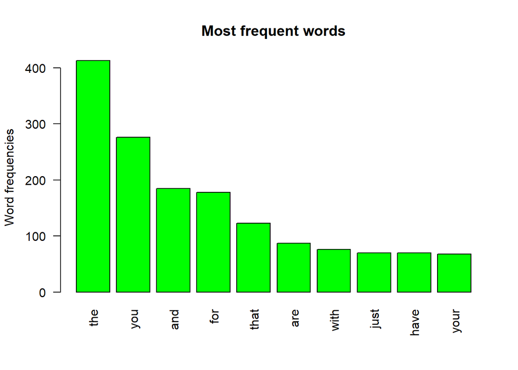

```r
barplot(d[1:10,]$freq, las = 2, names.arg = d[1:10,]$word,
        col ="green", main ="Most frequent words",
        ylab = "Word frequencies")
```

## Next steps

Some more processing is necessary before the next step. First, we’ll need to take out ‘stop words’ like ‘the’, ‘and’, ‘you’, etc. These would make our job in making a prediction algorithm too difficult. We’ll also need to get rid of curse words.

In order to build the algorithm, we’ll also need to create n-grams (specifically 1- 2- and 3-grams) in order to make reasonable predictions about what word the person will choose next.

The eventual Shiny app will likely consist of a text box where the user can enter one, two, or three words and, after pressing ‘OK’, will get a short list of words (5 or 10) which would best suit the n-gram they entered.

The algorithm behind the Shiny app will be trained on a subset of the data available. Unfortunately, there is too much data to be able to use it all and still have a fast-performing algorithm.